# DataRoot3

**DataRoot block 3**  
Honcharov Danylo.

**Used materials:**

Numpy:

- http://www.labri.fr/perso/nrougier/from-python-to-numpy/
- https://docs.scipy.org/doc/numpy/user/
- https://www.dataquest.io/blog/numpy-tutorial-python/
- https://github.com/rougier/numpy-tutorial

Scipy:

- https://docs.scipy.org/doc/scipy/reference/tutorial/index.html

Pandas:

- https://www.dataquest.io/blog/pandas-python-tutorial/
- http://www.gregreda.com/2013/10/26/intro-to-pandas-data-structures/
- http://www.gregreda.com/2013/10/26/working-with-pandas-dataframes/
- http://www.gregreda.com/2013/10/26/using-pandas-on-the-movielens-dataset/
- http://machinelearningmastery.com/quick-and-dirty-data-analysis-with-pandas/

Matplotlib:

- http://nbviewer.jupyter.org/github/whitehorn/Scientific_graphics_in_python/blob/master/P1%20Chapter%201%20Pyplot.ipynb
- https://pythonworld.ru/novosti-mira-python/scientific-graphics-in-python.html
- http://matplotlib.org/users/pyplot_tutorial.html
- https://www.dataquest.io/blog/matplotlib-tutorial/

Classification accuracy (metrics for quality assurance):

- http://bazhenov.me/blog/2012/07/21/classification-performance-evaluation.html
- http://scikit-learn.org/stable/modules/model_evaluation.html
- http://machinelearningmastery.com/classification-accuracy-is-not-enough-more-performance-measures-you-can-use/

Preprocessing data:

- http://machinelearningmastery.com/prepare-data-machine-learning-python-scikit-learn/

SVM theory:

- http://www.svm-tutorial.com/svm-tutorial/
- http://www.machinelearning.ru/wiki/index.php?title=SVM

Sequential minimal optimization:

- https://en.wikipedia.org/wiki/Sequential_minimal_optimization
- http://cs229.stanford.edu/notes/cs229-notes3.pdf
- http://mechanoid.kiev.ua/ml-svm.html
- https://github.com/LasseRegin/SVM-w-SMO

Neural networks:

- https://blog.dbrgn.ch/2013/3/26/perceptrons-in-python/
- https://www.youtube.com/playlist?list=PLiaHhY2iBX9hdHaRr6b7XevZtgZRa1PoU

**Author - Honcharov Danylo, project for DataRoot courses.**

> In this block students have to choose one of the several possible projects and do five task:
> - 1. Explore the data.
> - 2. Choose 2 models (maybe more if you want) and metrics for quality assurance.
> - 3. Implement the models and compare them.
> - 4. Make some conclusions and ways to improve result.
> - 5. Prepare iPython notebook and presentation.

> So, content of this IPython Notebook:
> - 1. Exploring the data!
> - 2.0. Preparing data.
> - 2.1. Choosing and implementing first model (logistic regression) Adjusting parameters.
> - 2.2. Choosing and implementing second model (svm). Playing with parameters.
> - 3. Conslusions. Ways to improve result

<font size=4 id="task1">**1. Task 1 - explore the data.** </font>  
Let's do it!

**Description of dataset:**

Gender Recognition by Voice and Speech Analysis

This database was created to identify a voice as male or female, based upon acoustic properties of the voice and speech. The dataset consists of 3,168 recorded voice samples, collected from male and female speakers. The voice samples are pre-processed by acoustic analysis in R using the seewave and tuneR packages, with an analyzed frequency range of 0hz-280hz (human vocal range).

The Dataset:

The following acoustic properties of each voice are measured and included within the CSV:

- meanfreq: mean frequency (in kHz)
- sd: standard deviation of frequency
- median: median frequency (in kHz)
- Q25: first quantile (in kHz)
- Q75: third quantile (in kHz)
- IQR: interquantile range (in kHz)
- skew: skewness (see note in specprop description)
- kurt: kurtosis (see note in specprop description)
- sp.ent: spectral entropy
- sfm: spectral flatness
- mode: mode frequency
- centroid: frequency centroid (see specprop)
- peakf: peak frequency (frequency with highest energy)
- meanfun: average of fundamental frequency measured across acoustic signal
- minfun: minimum fundamental frequency measured across acoustic signal
- maxfun: maximum fundamental frequency measured across acoustic signal
- meandom: average of dominant frequency measured across acoustic signal
- mindom: minimum of dominant frequency measured across acoustic signal
- maxdom: maximum of dominant frequency measured across acoustic signal
- dfrange: range of dominant frequency measured across acoustic signal
- modindx: modulation index. Calculated as the accumulated absolute difference between adjacent measurements of fundamental frequencies divided by the frequency range
- label: male or female

```python
import pandas as pd
data=pd.read_csv("voice.csv")
print(data.head())
print("Length of data (how many samples):",len(data))
```

```
   meanfreq        sd    median       Q25       Q75       IQR       skew  \
0  0.059781  0.064241  0.032027  0.015071  0.090193  0.075122  12.863462
1  0.066009  0.067310  0.040229  0.019414  0.092666  0.073252  22.423285
2  0.077316  0.083829  0.036718  0.008701  0.131908  0.123207  30.757155
3  0.151228  0.072111  0.158011  0.096582  0.207955  0.111374   1.232831
4  0.135120  0.079146  0.124656  0.078720  0.206045  0.127325   1.101174

          kurt    sp.ent       sfm  ...    centroid   meanfun    minfun  \
0   274.402906  0.893369  0.491918  ...    0.059781  0.084279  0.015702
1   634.613855  0.892193  0.513724  ...    0.066009  0.107937  0.015826
2  1024.927705  0.846389  0.478905  ...    0.077316  0.098706  0.015656
3     4.177296  0.963322  0.727232  ...    0.151228  0.088965  0.017798
4     4.333713  0.971955  0.783568  ...    0.135120  0.106398  0.016931

     maxfun   meandom    mindom    maxdom   dfrange   modindx  label
0  0.275862  0.007812  0.007812  0.007812  0.000000  0.000000   male
1  0.250000  0.009014  0.007812  0.054688  0.046875  0.052632   male
2  0.271186  0.007990  0.007812  0.015625  0.007812  0.046512   male
3  0.250000  0.201497  0.007812  0.562500  0.554688  0.247119   male
4  0.266667  0.712812  0.007812  5.484375  5.476562  0.208274   male

[5 rows x 21 columns]
Length of data (how many samples): 3168
```

Important question - is our data balanced?

```python
m_size=len(data[data['label']=='male'])
f_size=len(data[data['label']=='female'])
if(m_size==f_size):
           print("Data absolutely balanced")
           print("Each class containts:",m_size)
else:
           print("Data unbalanced")
           print("First class contains:",m_size," ,second:",f_size)
```

```
Data absolutely balanced
Each class containts: 1584
```

And let's look, maybe we have some null values:

```python
print(data.isnull().any())
```

```
meanfreq    False
sd          False
median      False
Q25         False
Q75         False
IQR         False
skew        False
kurt        False
sp.ent      False
sfm         False
mode        False
centroid    False
meanfun     False
minfun      False
maxfun      False
meandom     False
mindom      False
maxdom      False
dfrange     False
modindx     False
label       False
dtype: bool
```

Okay, we have 20 features and two classes. Let's see correlations between features (using pandas, of course, it's powerful)

```python
#data.corr().to_html('table.html') to html which we can format fo image
data.corr()
```

|  | meanfreq | sd | median | Q25 | Q75 | IQR | skew | kurt | sp.ent | sfm | mode | centroid | meanfun | minfun | maxfun | meandom | mindom | maxdom | dfrange | modindx |
| --- | --- | --- | --- | --- | --- | --- | --- | --- | --- | --- | --- | --- | --- | --- | --- | --- | --- | --- | --- | --- |
| meanfreq | 1.000000 | -0.739039 | 0.925445 | 0.911416 | 0.740997 | -0.627605 | -0.322327 | -0.316036 | -0.601203 | -0.784332 | 0.687715 | 1.000000 | 0.460844 | 0.383937 | 0.274004 | 0.536666 | 0.229261 | 0.519528 | 0.515570 | -0.216979 |
| sd | -0.739039 | 1.000000 | -0.562603 | -0.846931 | -0.161076 | 0.874660 | 0.314597 | 0.346241 | 0.716620 | 0.838086 | -0.529150 | -0.739039 | -0.466281 | -0.345609 | -0.129662 | -0.482726 | -0.357667 | -0.482278 | -0.475999 | 0.122660 |
| median | 0.925445 | -0.562603 | 1.000000 | 0.774922 | 0.731849 | -0.477352 | -0.257407 | -0.243382 | -0.502005 | -0.661690 | 0.677433 | 0.925445 | 0.414909 | 0.337602 | 0.251328 | 0.455943 | 0.191169 | 0.438919 | 0.435621 | -0.213298 |
| Q25 | 0.911416 | -0.846931 | 0.774922 | 1.000000 | 0.477140 | -0.874189 | -0.319475 | -0.350182 | -0.648126 | -0.766875 | 0.591277 | 0.911416 | 0.545035 | 0.320994 | 0.199841 | 0.467403 | 0.302255 | 0.459683 | 0.454394 | -0.141377 |
| Q75 | 0.740997 | -0.161076 | 0.731849 | 0.477140 | 1.000000 | 0.009636 | -0.206339 | -0.148881 | -0.174905 | -0.378198 | 0.486857 | 0.740997 | 0.155091 | 0.258002 | 0.285584 | 0.359181 | -0.023750 | 0.335114 | 0.335648 | -0.216475 |
| IQR | -0.627605 | 0.874660 | -0.477352 | -0.874189 | 0.009636 | 1.000000 | 0.249497 | 0.316185 | 0.640813 | 0.663601 | -0.403764 | -0.627605 | -0.534462 | -0.222680 | -0.069588 | -0.333362 | -0.357037 | -0.337877 | -0.331563 | 0.041252 |
| skew | -0.322327 | 0.314597 | -0.257407 | -0.319475 | -0.206339 | 0.249497 | 1.000000 | 0.977020 | -0.195459 | 0.079694 | -0.434859 | -0.322327 | -0.167668 | -0.216954 | -0.080861 | -0.336848 | -0.061608 | -0.305651 | -0.304640 | -0.169325 |
| kurt | -0.316036 | 0.346241 | -0.243382 | -0.350182 | -0.148881 | 0.316185 | 0.977020 | 1.000000 | -0.127644 | 0.109884 | -0.406722 | -0.316036 | -0.194560 | -0.203201 | -0.045667 | -0.303234 | -0.103313 | -0.274500 | -0.272729 | -0.205539 |
| sp.ent | -0.601203 | 0.716620 | -0.502005 | -0.648126 | -0.174905 | 0.640813 | -0.195459 | -0.127644 | 1.000000 | 0.866411 | -0.325298 | -0.601203 | -0.513194 | -0.305826 | -0.120738 | -0.293562 | -0.294869 | -0.324253 | -0.319054 | 0.198074 |
| sfm | -0.784332 | 0.838086 | -0.661690 | -0.766875 | -0.378198 | 0.663601 | 0.079694 | 0.109884 | 0.866411 | 1.000000 | -0.485913 | -0.784332 | -0.421066 | -0.362100 | -0.192369 | -0.428442 | -0.289593 | -0.436649 | -0.431580 | 0.211477 |
| mode | 0.687715 | -0.529150 | 0.677433 | 0.591277 | 0.486857 | -0.403764 | -0.434859 | -0.406722 | -0.325298 | -0.485913 | 1.000000 | 0.687715 | 0.324771 | 0.385467 | 0.172329 | 0.491479 | 0.198150 | 0.477187 | 0.473775 | -0.182344 |
| centroid | 1.000000 | -0.739039 | 0.925445 | 0.911416 | 0.740997 | -0.627605 | -0.322327 | -0.316036 | -0.601203 | -0.784332 | 0.687715 | 1.000000 | 0.460844 | 0.383937 | 0.274004 | 0.536666 | 0.229261 | 0.519528 | 0.515570 | -0.216979 |
| meanfun | 0.460844 | -0.466281 | 0.414909 | 0.545035 | 0.155091 | -0.534462 | -0.167668 | -0.194560 | -0.513194 | -0.421066 | 0.324771 | 0.460844 | 1.000000 | 0.339387 | 0.311950 | 0.270840 | 0.162163 | 0.277982 | 0.275154 | -0.054858 |
| minfun | 0.383937 | -0.345609 | 0.337602 | 0.320994 | 0.258002 | -0.222680 | -0.216954 | -0.203201 | -0.305826 | -0.362100 | 0.385467 | 0.383937 | 0.339387 | 1.000000 | 0.213987 | 0.375979 | 0.082015 | 0.317860 | 0.316486 | 0.002042 |
| maxfun | 0.274004 | -0.129662 | 0.251328 | 0.199841 | 0.285584 | -0.069588 | -0.080861 | -0.045667 | -0.120738 | -0.192369 | 0.172329 | 0.274004 | 0.311950 | 0.213987 | 1.000000 | 0.337553 | -0.243426 | 0.355390 | 0.359880 | -0.363029 |
| meandom | 0.536666 | -0.482726 | 0.455943 | 0.467403 | 0.359181 | -0.333362 | -0.336848 | -0.303234 | -0.293562 | -0.428442 | 0.491479 | 0.536666 | 0.270840 | 0.375979 | 0.337553 | 1.000000 | 0.099656 | 0.812838 | 0.811304 | -0.180954 |
| mindom | 0.229261 | -0.357667 | 0.191169 | 0.302255 | -0.023750 | -0.357037 | -0.061608 | -0.103313 | -0.294869 | -0.289593 | 0.198150 | 0.229261 | 0.162163 | 0.082015 | -0.243426 | 0.099656 | 1.000000 | 0.026640 | 0.008666 | 0.200212 |
| maxdom | 0.519528 | -0.482278 | 0.438919 | 0.459683 | 0.335114 | -0.337877 | -0.305651 | -0.274500 | -0.324253 | -0.436649 | 0.477187 | 0.519528 | 0.277982 | 0.317860 | 0.355390 | 0.812838 | 0.026640 | 1.000000 | 0.999838 | -0.425531 |
| dfrange | 0.515570 | -0.475999 | 0.435621 | 0.454394 | 0.335648 | -0.331563 | -0.304640 | -0.272729 | -0.319054 | -0.431580 | 0.473775 | 0.515570 | 0.275154 | 0.316486 | 0.359880 | 0.811304 | 0.008666 | 0.999838 | 1.000000 | -0.429266 |
| modindx | -0.216979 | 0.122660 | -0.213298 | -0.141377 | -0.216475 | 0.041252 | -0.169325 | -0.205539 | 0.198074 | 0.211477 | -0.182344 | -0.216979 | -0.054858 | 0.002042 | -0.363029 | -0.180954 | 0.200212 | -0.425531 | -0.429266 | 1.000000 |

Oooh, we have some new information.  
Let's go ahead with exploring data. Actually, we cave very intresting function - "describe". Let's use it.

```python
#data.describe().to_html('presentation/describe.html')# to html which we can format fo image
data.describe()
```

|  | meanfreq | sd | median | Q25 | Q75 | IQR | skew | kurt | sp.ent | sfm | mode | centroid | meanfun | minfun | maxfun | meandom | mindom | maxdom | dfrange | modindx |
| --- | --- | --- | --- | --- | --- | --- | --- | --- | --- | --- | --- | --- | --- | --- | --- | --- | --- | --- | --- | --- |
| count | 3168.000000 | 3168.000000 | 3168.000000 | 3168.000000 | 3168.000000 | 3168.000000 | 3168.000000 | 3168.000000 | 3168.000000 | 3168.000000 | 3168.000000 | 3168.000000 | 3168.000000 | 3168.000000 | 3168.000000 | 3168.000000 | 3168.000000 | 3168.000000 | 3168.000000 | 3168.000000 |
| mean | 0.180907 | 0.057126 | 0.185621 | 0.140456 | 0.224765 | 0.084309 | 3.140168 | 36.568461 | 0.895127 | 0.408216 | 0.165282 | 0.180907 | 0.142807 | 0.036802 | 0.258842 | 0.829211 | 0.052647 | 5.047277 | 4.994630 | 0.173752 |
| std | 0.029918 | 0.016652 | 0.036360 | 0.048680 | 0.023639 | 0.042783 | 4.240529 | 134.928661 | 0.044980 | 0.177521 | 0.077203 | 0.029918 | 0.032304 | 0.019220 | 0.030077 | 0.525205 | 0.063299 | 3.521157 | 3.520039 | 0.119454 |
| min | 0.039363 | 0.018363 | 0.010975 | 0.000229 | 0.042946 | 0.014558 | 0.141735 | 2.068455 | 0.738651 | 0.036876 | 0.000000 | 0.039363 | 0.055565 | 0.009775 | 0.103093 | 0.007812 | 0.004883 | 0.007812 | 0.000000 | 0.000000 |
| 25% | 0.163662 | 0.041954 | 0.169593 | 0.111087 | 0.208747 | 0.042560 | 1.649569 | 5.669547 | 0.861811 | 0.258041 | 0.118016 | 0.163662 | 0.116998 | 0.018223 | 0.253968 | 0.419828 | 0.007812 | 2.070312 | 2.044922 | 0.099766 |
| 50% | 0.184838 | 0.059155 | 0.190032 | 0.140286 | 0.225684 | 0.094280 | 2.197101 | 8.318463 | 0.901767 | 0.396335 | 0.186599 | 0.184838 | 0.140519 | 0.046110 | 0.271186 | 0.765795 | 0.023438 | 4.992188 | 4.945312 | 0.139357 |
| 75% | 0.199146 | 0.067020 | 0.210618 | 0.175939 | 0.243660 | 0.114175 | 2.931694 | 13.648905 | 0.928713 | 0.533676 | 0.221104 | 0.199146 | 0.169581 | 0.047904 | 0.277457 | 1.177166 | 0.070312 | 7.007812 | 6.992188 | 0.209183 |
| max | 0.251124 | 0.115273 | 0.261224 | 0.247347 | 0.273469 | 0.252225 | 34.725453 | 1309.612887 | 0.981997 | 0.842936 | 0.280000 | 0.251124 | 0.237636 | 0.204082 | 0.279114 | 2.957682 | 0.458984 | 21.867188 | 21.843750 | 0.932374 |

This is some statistical data about out statistical data and we need to go deeper(std - standart deviation, other row names quite selfdiscriptive). Can we build some histograms? This is a piece of cake:

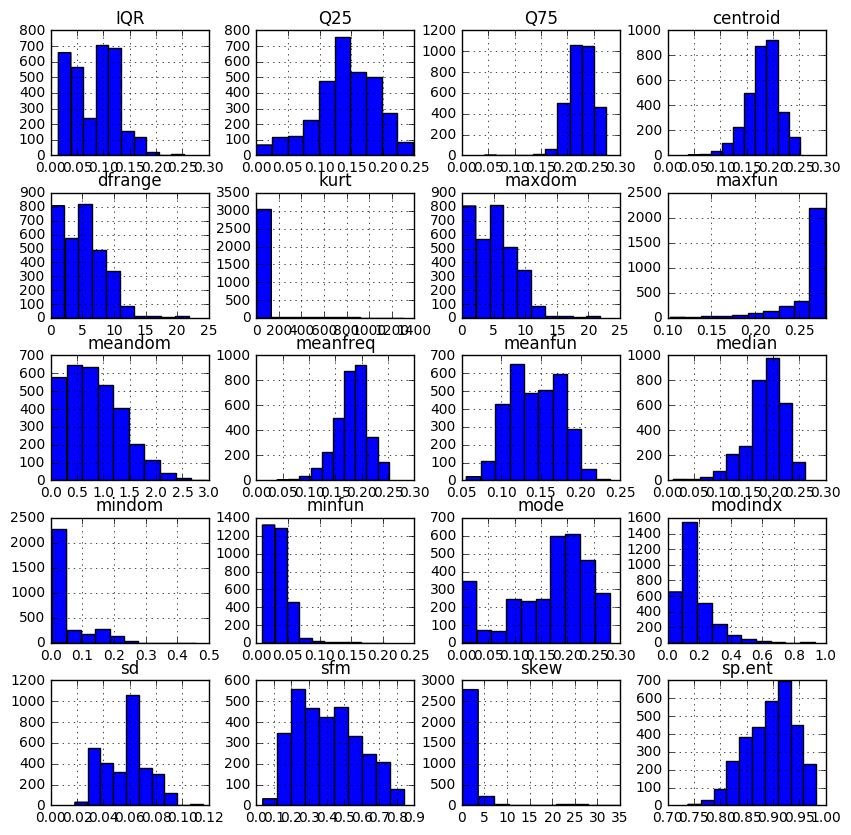

```python
#%matplotlib inline
import matplotlib
import matplotlib.pyplot as plt


%matplotlib inline

data.hist(figsize=(10,10)) #setting size of matplotlib window, cause default size is too small
print("") #clearing unnessesary information
```

Maybe it's good idea to look at the differences of the features aside for male and female voices. Let's look.

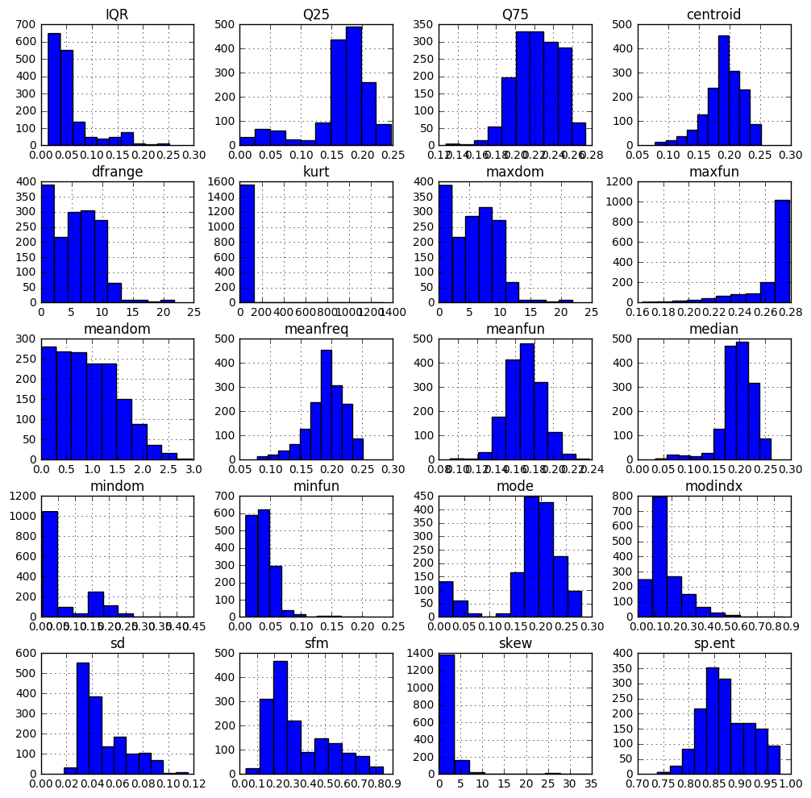

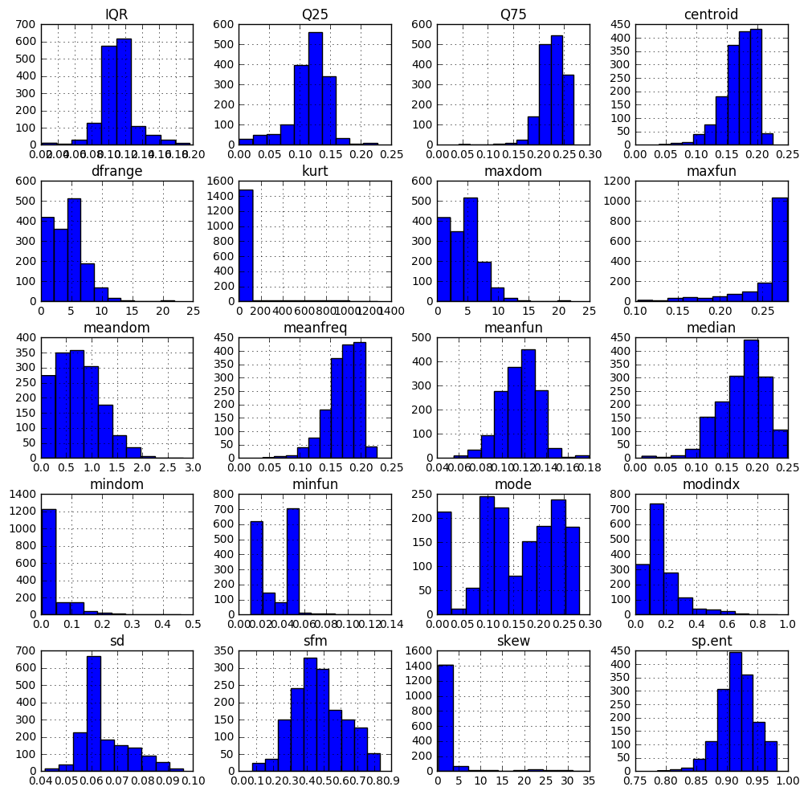

```python
%matplotlib inline
data.groupby("label").hist(figsize=(12,12)) #setting size of matplotlib window, cause default size is too small
print("") #clearing unnessesary information
```

So, we can assume that the features really different for this classes. For instance - we can look on differences on meanfun,meanfreq,IQR,mode features:

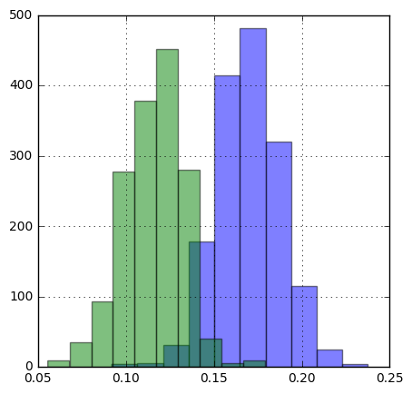

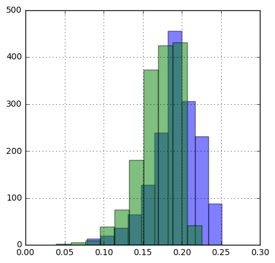

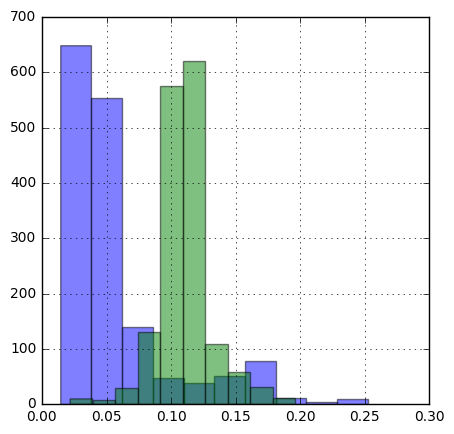

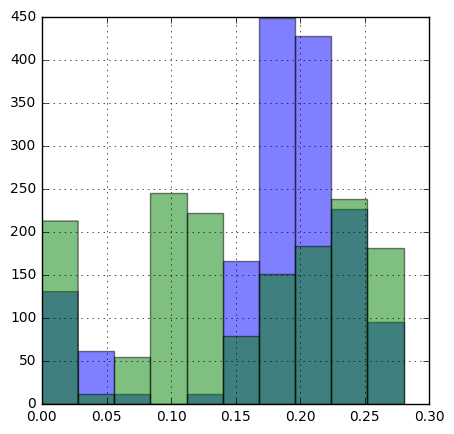

```python
%matplotlib inline
import matplotlib.pyplot as plt
data.groupby("label").meanfun.hist(figsize=(5,5),alpha=0.5)
fig, axes = plt.subplots()
data.groupby("label").meanfreq.hist(figsize=(5,5),alpha=0.5)
fig, axes = plt.subplots()
data.groupby("label").IQR.hist(figsize=(5,5),alpha=0.5)
fig, axes = plt.subplots()
data.groupby("label").mode.hist(figsize=(5,5),alpha=0.5)
print("") #clearing unnessesary information
```

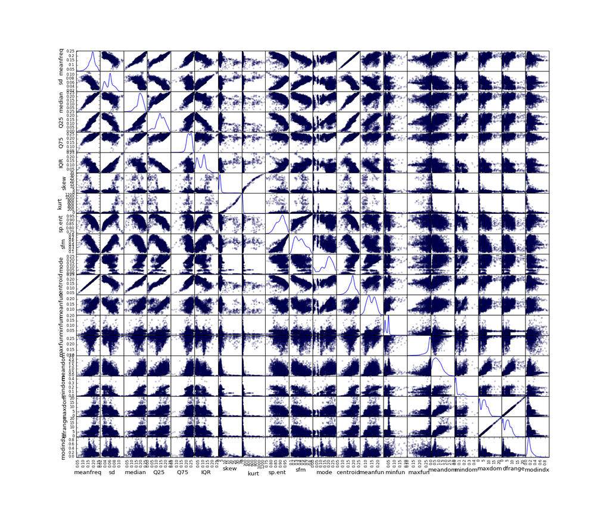

```python
%matplotlib notebook
from pandas.tools.plotting import scatter_matrix
scatter_matrix(data, alpha=0.2, figsize=(18, 15), diagonal='kde')
print("") #clearing unnessesary information
```

Okay, we can assume possible correlation between dfrange and maxdom features, between kurt and skew, between meanfreq and centroid and so on.

<font size=4 id="prepare"> **2. Task 2 - choose 2 models and metrics for quality assurance.** </font>  
<font size=3> 2.0. Preparing data.</font>  
First, we should to prepare data. We need to split it into train and test cases.  
How we can do it? We can do it in pandas way:

```python
procent_of_train_data=0.9 #how many data will be in train case
data_for_splitting=data.sample(frac=1).reset_index(drop=True) #the problem is that 'label' field in data is ordered
#so we can't just split it, we need to shuffle it first
train_data=data_for_splitting[:(int(len(data)*procent_of_train_data))]
test_data=data_for_splitting[(int(len(data)*procent_of_train_data)):]
print("Length of train data:",len(train_data))
print("Length of test data:",len(test_data))
```

```
Length of train data: 2851
Length of test data: 317
```

Of course, it possible to use scikit-learn library, just like that:

```python
from sklearn.model_selection import train_test_split
procent_of_train_data=0.9
data_x=data.iloc[:,:-1]
data_y=data['label']
train_data_x,test_data_x,train_data_y,test_data_y=train_test_split(data_x,data_y,train_size=procent_of_train_data)
print(len(train_data_x))
print(len(test_data_x))
```

```
2851
317
```

Sklearn way look better to me. I will use the result of train_test_split instead of pandas result in future.  
Next, is look like a good idea to apply "standardization" to data. ("Standardization" - is making the mean of features 0 and making the deviation 1).  
I tried to run classification without this, and it's worked, but after standardization the quality of classification really increased. So, let's do it!

```python
from sklearn.preprocessing import StandardScaler
scaler = StandardScaler()
train_data_x=scaler.fit_transform(train_data_x)
test_data_x=scaler.transform(test_data_x)
data_x=scaler.transform(data_x)
print(train_data_x.mean())
print(train_data_x.std())
```

```
-3.17139821555e-17
1.0
```

Also we need to encode labels (BTW, all working without label encoding, but if we [read this](http://stats.stackexchange.com/questions/134427/in-practice-why-do-we-convert-categorical-class-labels-to-integers-for-classifi), we will understand that it's good thing to do):

```python
from sklearn.preprocessing import LabelEncoder
le=LabelEncoder()
data_y=le.fit_transform(data_y)
test_data_y=le.fit_transform(test_data_y)
train_data_y=le.fit_transform(train_data_y)
print(data_y)
```

```
[1 1 1 ..., 0 0 0]
```

<font size=3 id="first">2.1. Choosing and implementing first model.</font>  
Okay, data is prepared.

Next, I should choose models. I'm intresting in trying logistic regression. Why?  
Because I want to see how this not very complicated model can deal with this data.

```python
from sklearn import linear_model
regress_skl=linear_model.LogisticRegression()
regress_skl.fit(train_data_x,train_data_y)
print(regress_skl.score(test_data_x,test_data_y))
```

```
0.977917981073
```

Logistic regression with default parametres worked well, but we have some moments.  
Firstly, accuracy value depends on how exactly we splitted data. Secondly - now we haven't tried some extra parameters (like regularization) yet.  
Let's find the best C (regularization) value and play with cross-validation:

```
Best accuracy: 0.967836955656  best C: 0.2
```

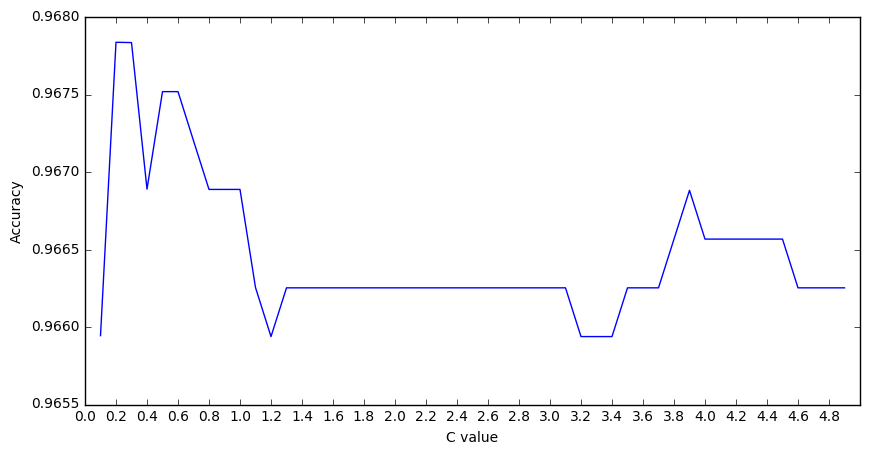

```python
from sklearn.model_selection import cross_val_score #importing cross-validation
import matplotlib.pyplot as plt

import numpy as np
mean_results={}
best_c=0
best_accuracy=0.1 #some low accuracy
for c in np.arange(0.1,5,0.1):
    regress_skl=linear_model.LogisticRegression(C=c)
    scores=cross_val_score(regress_skl,data_x,data_y,cv=10)
    mean_results[c]=scores.mean()
    if(best_accuracy<scores.mean()):
        best_accuracy=scores.mean()
        best_c=c
print("Best accuracy:",best_accuracy," best C:",best_c)
#print(mean_results)
%matplotlib inline
plt.figure(figsize=(10,5))
plt.plot(list(mean_results.keys()),list(mean_results.values()))
plt.xlabel("C value")
plt.ylabel("Accuracy")
plt.xticks(np.arange(0,5,0.2))
print("") #cleaning mess
```

It's look better, and we can be sure that we know the best C value.

**But how do we interpret C <1?**

Okay, in logistic regression and svm C<1 means stronger regularization.  
So, if we have better result with smaller C - we can suppose that our default model was overfitted.

As we see, even simple logistic regression algorithm can perform really good.  
But how about custom realization of logistic regression, using numpy and scipy.optimize? Let's look:

```python
import numpy as np
from sklearn import preprocessing
from scipy.optimize import minimize

class Logistic_Regression_custom:
    def __init__(self):
        self.coefs=[]

    def f(self,x_vectors,param):
        x_vectors=np.array(x_vectors,np.float128)
        params_multipl_by_vectors=param[1:]*x_vectors
        sum_of_all=param[1]+np.sum(params_multipl_by_vectors,axis=1)
        #print(sum_of_all.max())
        sum_of_all=np.exp((-1)*sum_of_all)
        sum_of_all=1/(1+sum_of_all)
        sum_of_all[sum_of_all==1]=0.999999999999999  #very lame code,avoiding zero in log
        return sum_of_all

    def function(self,param):
        model=self.model
        log_sum=0
        for m in model.keys():
            f_value=self.f(model[m],param)
            log_sum+=(m*np.log(f_value)+(1-m)*np.log(1-f_value)).sum()
        log_sum/=-1*(len(model[0])+len(model[1]))
        return log_sum

    def train(self, X, y):
        X=np.array(X)
        y=np.array(y)
        self.model = {}
        #self.le = preprocessing.LabelEncoder()
        #y = list(y)
        #y = self.le.fit_transform(y)
        for current in range(len(y)):
            if y[current] in self.model:
                self.model[y[current]].append(X[current])
            else:
                self.model[y[current]] = [X[current]]
        x0 = np.random.rand(X.shape[1] + 1)
        self.coefs = minimize(self.function,x0).x
        #print(self.coefs)

    def score(self,X,y):
        if(len(self.coefs)==0):
            return 0;
        X=np.array(X)
        function_values=self.f(X,self.coefs)
        function_values[function_values>=0.5]=1
        function_values[function_values<0.5]=0
        difference=np.fabs(function_values-y)
        correct_sum=len(y)-difference.sum()
        return (correct_sum/len(y)) #return accuracy of test case

regress=Logistic_Regression_custom()
regress.train(train_data_x, train_data_y)
print(regress.score(test_data_x,test_data_y))
```

```
0.965299684543
```

Okay, but what is a number, which we get?  
It's **accuracy**. It's just result of dividing between amount correctly recognized test cases and amount of all test cases.  
What other metrics we can use for understanding, how good our classificator works? Okay, other possible metrics is **precision** ("точность") and **recall** ("полнота") and **f-measure**.  
Also, we can look at confusion matrix. We can calculate it, using next values for each class - "true positive", "true negative", "false positive" and "false negative".

```python
class RegressionEvaluator:
    def __init__(self,regress_object):
        self.regress=regress_object
    def evaluate(self,X,y):
        if(len(self.regress.coefs)==0):
            return 0;
        X=np.array(X)
        function_values=self.regress.f(X,self.regress.coefs)
        function_values[function_values>=0.5]=1
        function_values[function_values<0.5]=0
        difference=np.fabs(function_values-y)
        correct_sum=len(y)-difference.sum()
        self.calculate_accuracy_measures(function_values, y)
        self.print_accuracy_data()

    def print_confusion_matrix(self):
        print("Confusion matrix:")
        print("\tMale\tFemale")
        print("Male:  ",self.male_true_positive,"\t",self.male_false_positive)
        print("Female:", self.male_false_negative, "\t", self.male_true_negative)
        print("\r\n")

    def print_f_measures(self):
        print("Male f_measure",self.f_measure_male)
        print("Female f_measure", self.f_measure_female)

    def calculate_accuracy_measures(self, function_values, y):
        signed_differ = function_values - y
        self.male_true_positive = len(function_values[(signed_differ==0) & (y == 1)])
        self.female_true_positive = len(function_values[(signed_differ==0) & (y == 0)])
        self.male_true_negative = self.female_true_positive
        self.female_true_negative = self.male_true_positive
        self.male_false_positive = len(function_values[(signed_differ == 1 ) & (y == 0)])
        self.male_false_negative = len(function_values[(signed_differ == -1) & (y == 1)])
        self.female_false_positive = self.male_false_negative
        self.female_false_negative = self.male_false_positive
        self.male_precision=self.male_true_positive/(self.male_true_positive+self.male_false_positive)
        self.male_recall=self.male_true_positive/(self.male_true_positive+self.male_false_negative)
        self.female_precision = self.female_true_positive / (self.female_true_positive + self.female_false_positive)
        self.female_recall = self.female_true_positive / (self.female_true_positive + self.female_false_negative)
        self.f_measure_male=2*(self.male_precision*self.male_recall)/(self.male_precision+self.male_recall)
        self.f_measure_female=2*(self.female_precision*self.female_recall)/(self.female_precision+self.female_recall)

    def print_accuracy_data(self):
        self.print_confusion_matrix()
        self.print_f_measures()
evaluator=RegressionEvaluator(regress)
evaluator.evaluate(test_data_x,test_data_y)
```

```
Confusion matrix:
	Male	Female
Male:   156 	 7
Female: 4 	 150


Male f_measure 0.9659442724458206
Female f_measure 0.9646302250803858
```

Hm, we can also evaluate our sklearn regression classifier. Let's look:

```python
from sklearn.model_selection import cross_val_score
from sklearn.metrics import confusion_matrix
regress_skl=linear_model.LogisticRegression()
regress_skl.fit(train_data_x,train_data_y)
print("Accuracy:",cross_val_score(regress_skl,test_data_x,test_data_y,scoring="accuracy"))
print("Average f1:",cross_val_score(regress_skl,test_data_x,test_data_y,scoring="f1_macro"))
print("Confusion matrix:\r\n",confusion_matrix(regress_skl.predict(test_data_x),test_data_y))
```

```
Accuracy: [ 0.97196262  0.96190476  0.98095238]
Average f1: [ 0.97196262  0.96181818  0.98095065]
Confusion matrix:
 [[150   3]
 [  7 157]]
```

<font size=3 id="second">2.2. Choosing and implementing second model.</font>  
What other model should I choose? I'm going to use svm model.  
Why? There is one valuable reason - I had (and maybe have for now) some problem with understanding it.  
So, let's do svm classification (and let's try some varied kernels):

```python
from sklearn import svm
svm_model = svm.SVC()
svm_model.fit(train_data_x,train_data_y)
print("Default kernel (RBF) result:",svm_model.score(test_data_x,test_data_y))

svm_model = svm.SVC(kernel="linear")
svm_model.fit(train_data_x,train_data_y)
print("Linear kernel result:",svm_model.score(test_data_x,test_data_y))

svm_model = svm.SVC(kernel="poly")
svm_model.fit(train_data_x,train_data_y)
print("Poly kernel result:",svm_model.score(test_data_x,test_data_y))

svm_model = svm.SVC(kernel="sigmoid")
svm_model.fit(train_data_x,train_data_y)
print("Sigmoid kernel result:",svm_model.score(test_data_x,test_data_y))
```

```
Default kernel (RBF) result: 0.990536277603
Linear kernel result: 0.977917981073
Poly kernel result: 0.958990536278
Sigmoid kernel result: 0.798107255521
```

**How this kernels functions looks like?**

RBF - Radial basis function:

$$K(x,x')=\exp(-\frac{\parallel{x-x'}\parallel^2}{(2\sigma^2)})$$

Linear kernel function:

$$K(x,x')=x^Tx'$$

Polynomial (poly) kernel function:

$$K(x,x')=(x^Tx'+r)^n$$

Sigmoid kernel function:

```python
from sklearn.model_selection import cross_val_score

svm_model = svm.SVC()
scores=cross_val_score(svm_model,data_x,data_y,cv=5)
print("Rbf CV mean",scores.mean())

svm_model = svm.SVC(kernel="linear")
scores=cross_val_score(svm_model,data_x,data_y,cv=5)
print("Linear CV mean",scores.mean())


svm_model = svm.SVC(kernel='poly')
scores=cross_val_score(svm_model,data_x,data_y,cv=5)
print("Poly CV mean",scores.mean())

svm_model = svm.SVC(kernel="sigmoid")
scores=cross_val_score(svm_model,data_x,data_y,cv=5)
print("Sigmoid CV mean",scores.mean())
```

```
Rbf CV mean 0.967796390209
Linear CV mean 0.967175458212
Poly CV mean 0.941281994969
Sigmoid CV mean 0.776155013377
```

Okay, this was only svm with default parameters.  
How about adjusting additional parameters?  
I propose create special class for this purpose. Something like this:

```python
from sklearn.model_selection import cross_val_score #importing cross-validation
import matplotlib.pyplot as plt
import numpy as np
class Finder_Best_Params_For_SVM:
    def __init__(self,kernel_type,constant_params,tuning_parameter,interval,plot_x_interval):
        mean_results={}
        best_value=0
        best_accuracy=0.1 #some low accuracy
        keywords_params={}
        keywords_params['kernel']=kernel_type
        for c in constant_params.keys():
            keywords_params[c]=constant_params[c]
        for v in interval:
            keywords_params[tuning_parameter]=v
            svm_model=svm.SVC(**keywords_params)
            scores=cross_val_score(svm_model,data_x,data_y,cv=10)
            mean_results[v]=scores.mean()
            if(best_accuracy<scores.mean()):
                best_accuracy=scores.mean()
                best_value=v
        print("Best accuracy:",best_accuracy," best value:",best_value)
        #print(mean_results)
        %matplotlib inline
        plt.figure(figsize=(10,5))
        plt.plot(list(mean_results.keys()),list(mean_results.values()))
        plt.xlabel(tuning_parameter+" value")
        plt.ylabel("Accuracy")
        plt.xticks(plot_x_interval)
        print("") #cleaning mess
```

Let's start from **rbf** kernel.  
By documentation, we have next parameters, which have influence on rbf kernel: C and gamma. Finding best C:

```
Best accuracy: 0.968151421065  best value: 0.7
```

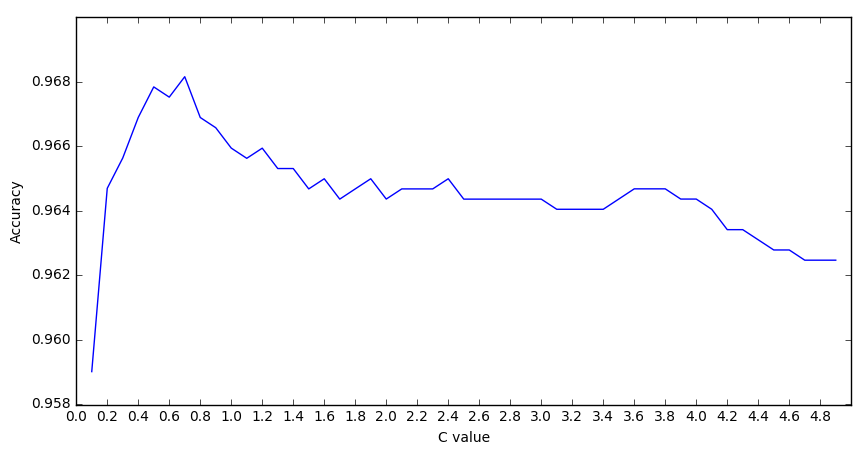

```python
finder=Finder_Best_Params_For_SVM("rbf",{},"C",list(np.arange(0.1,5,0.1)),list(np.arange(0,5,0.2)))
```

Finding best gamma:

```
Best accuracy: 0.964043467877  best value: 0.1
```

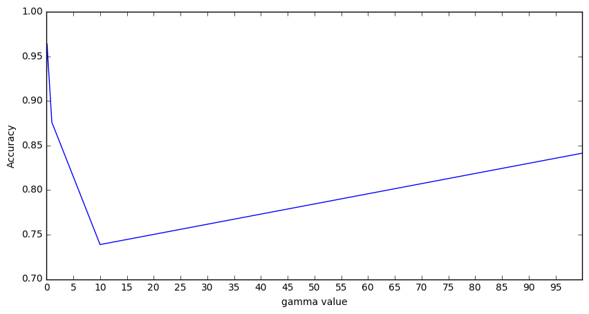

```python
finder=Finder_Best_Params_For_SVM("rbf",{"C":0.7},"gamma",[0.00001,0.001,0.1,1,10,100],list(range(0,100,5)))
```

Let's look on gamma in range 0.001 and 0.2 closer:

```
Best accuracy: 0.967834965369  best value: 0.031
```

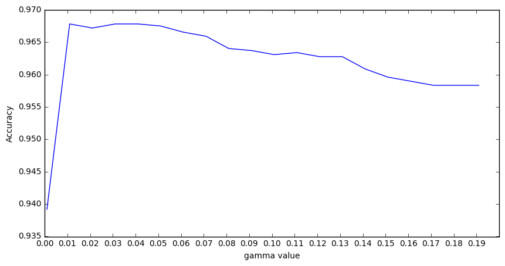

```python
finder=Finder_Best_Params_For_SVM("rbf",{"C":0.7},"gamma",list(np.arange(0.001,0.2,0.01)),list(np.arange(0,0.2,0.01)))
```

Next, I want to find best C parameter for **linear** kernel:

```
Best accuracy: 0.970048164955  best value: 0.1
```

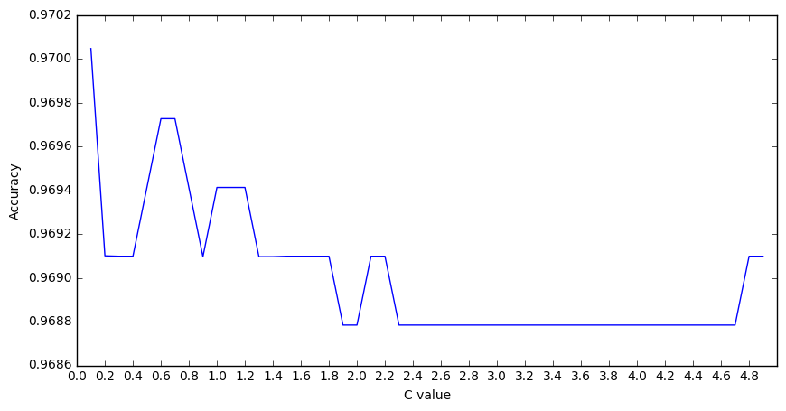

```python
finder=Finder_Best_Params_For_SVM("linear",{},"C",list(np.arange(0.1,5,0.1)),list(np.arange(0,5,0.2)))
```

Next, we can tune parameters for **polynomial** kernel. By documentation, we also can tune C and degree parameter (and gamma):

```
Best accuracy: 0.95524639758  best value: 18.1
```

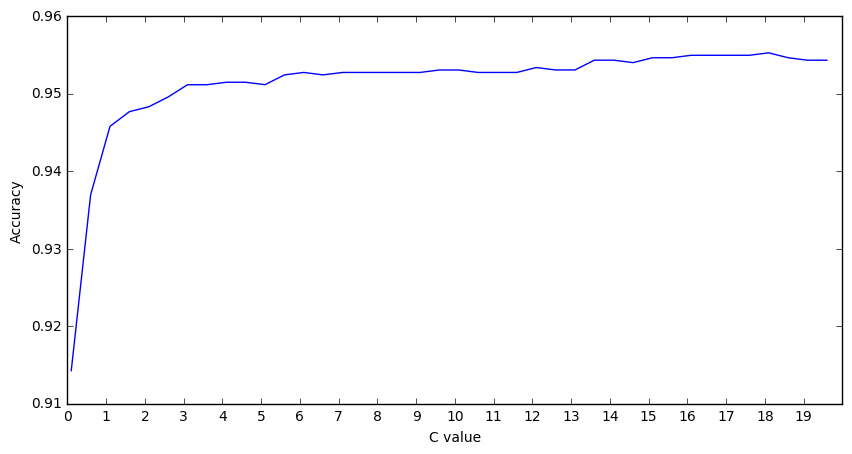

```python
finder=Finder_Best_Params_For_SVM("poly",{},"C",list(np.arange(0.1,20,0.5)),list(np.arange(0,20,1)))
```

We see something strange,have no idea how we can interpret this result. Maybe, value C=1 creating too much regularization?  
Let's look on degree values with C=18:

```
Best accuracy: 0.969096807579  best value: 1.0
```

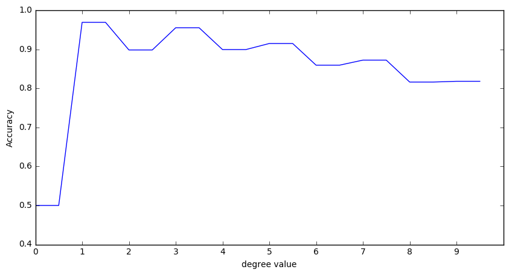

```python
finder=Finder_Best_Params_For_SVM("poly",{"C":18},"degree",list(np.arange(0,10,0.5)),list(np.arange(0,10,1)))
```

It's [known](https://www.kaggle.com/nirajvermafcb/d/primaryobjects/voicegender/support-vector-machine-detail-analysis) that on this dataset with this kernel best degree value with C=1 is default value(degree=3).  
But with big C value the best result of classifier is when degree=1 (BTW, total accuracy result in this case is better than with C=1 and degree=3)

How about a **sigmoid** kernel? It has the worse result with default parameters.  
But maybe if we adjust parameters we will have better result? For C:

```
Best accuracy: 0.899480534989  best value: 0.01
```

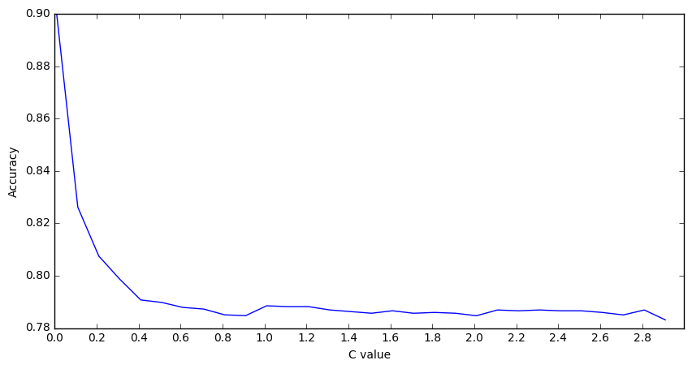

```python
finder=Finder_Best_Params_For_SVM("sigmoid",{},"C",list(np.arange(0.01,3,0.1)),list(np.arange(0,3,0.2)))
```

And gamma:

```
Best accuracy: 0.844823262479  best value: 0.1
```

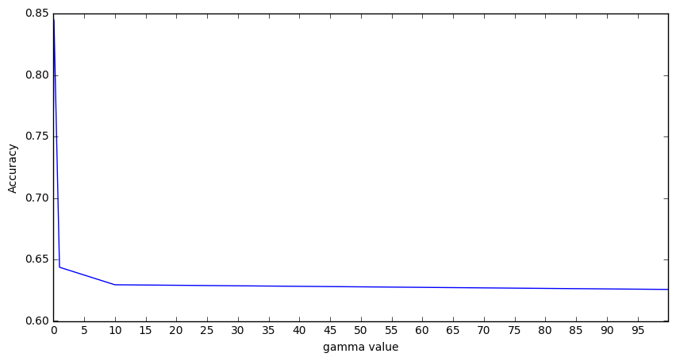

```python
finder=Finder_Best_Params_For_SVM("sigmoid",{"C":0.01},"gamma",[0.00001,0.001,0.1,1,10,100],list(range(0,100,5)))
```

Gamma on 0.01-0.2 :

```
Best accuracy: 0.898220683067  best value: 0.051
```

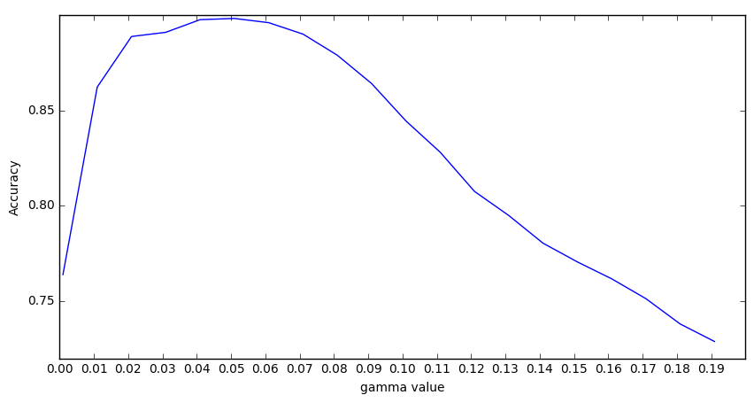

```python
finder=Finder_Best_Params_For_SVM("sigmoid",{"C":0.01},"gamma",list(np.arange(0.001,0.2,0.01)),list(np.arange(0,0.2,0.01)))
```

Last,let's use Grid search to find best parameters combination (okay, it's really long process):

```python
from sklearn.grid_search import GridSearchCV
from sklearn.metrics import classification_report
svm_model= svm.SVC()
param_grid={
    "C":list(np.arange(0.1,3,0.1)),"kernel":["linear"],
    "C":list(np.arange(0.1,3,0.1)),"kernel":["rbf"],"gamma":list(np.arange(0.001,0.2,0.02)),
    "C":list(np.arange(0.1,20,1)),"kernel":["poly"],"degree":list(np.arange(0,5,0.1)),"gamma":list(np.arange(0.001,0.2,0.03)),
}
best_svm = GridSearchCV(svm_model, param_grid,cv=5)
best_svm.fit(train_data_x,train_data_y)
print(best_svm.best_params_)
print(best_svm.score(test_data_x,test_data_y))
print(classification_report(test_data_y,best_svm.predict(test_data_x)))
```

[output not shown]

But how about a NN clasifier? We can look on Multi Layer Perceptron from sklearn:

```python
from sklearn.neural_network import MLPClassifier
from sklearn.model_selection import cross_val_score #importing cross-validation

mlp=MLPClassifier(solver='lbfgs',
                     hidden_layer_sizes=(data_x.shape[1], 1))
scores=cross_val_score(mlp,data_x,data_y,cv=10)
print(scores.mean())
#mlp.fit(train_data_x,train_data_y)
#print(mlp.score(test_data_x,test_data_y))
```

```
0.948598837672
```

```python
class Perceptron:
    def unit_step(self,result):
        result[result<0]=0
        result[result!=0]=1
        return result

    def __init__(self,features_len,X,y,n=5000,start_eta=0.2):
        self.w=np.random.rand(features_len)
        #self.errors = []
        self.n = n #iterations
        self.start_eta=start_eta
        self.eta =self.start_eta  # learning rate

        for i in range(self.n):
            result=np.dot(self.w,X.T)
            error=y-self.unit_step(result)
            #self.errors.append(error)
            changers=self.eta * error.reshape(error.size,1) * X
            self.w += np.sum(changers,axis=0)
            self.eta=self.start_eta*((self.n-i+1)/self.n)
        #print(self.eta)

    def predict(self,X):
        return self.unit_step(np.dot(self.w,X.T))

    def score(self,X,y):
        prediction=self.predict(X)
        differ=sum(np.fabs(prediction-y))
        return (len(y)-differ)/len(y)

p=Perceptron(np.array(train_data_x).shape[1],np.array(train_data_x),np.array(train_data_y))
print(p.score(test_data_x,test_data_y))
```

```
0.952681388013
```

How about tuning starting learning rate?

```
Best accuracy: 0.959621451104  best value: 0.1001
```

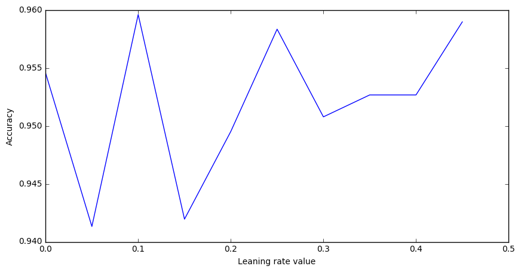

```python
class Finder_Best_Params_For_Perceptron:
    def __init__(self,interval,plot_x_interval,cv=5):
        mean_results={}
        best_value=0
        best_accuracy=0.1 #some low accuracy
        for v in interval:
            scores=0
            for i in range(cv):
                procent_of_train_data=0.9
                train_data_x,test_data_x,train_data_y,test_data_y=train_test_split(data_x,data_y,train_size=procent_of_train_data)
                p=Perceptron(np.array(train_data_x).shape[1],np.array(train_data_x),np.array(train_data_y),start_eta=v)
                scores+=p.score(test_data_x,test_data_y)
            scores/=cv
            mean_results[v]=scores
            if(best_accuracy<scores):
                best_accuracy=scores
                best_value=v
        print("Best accuracy:",best_accuracy," best value:",best_value)
        #print(mean_results)
        %matplotlib inline
        plt.figure(figsize=(10,5))
        plt.plot(list(mean_results.keys()),list(mean_results.values()))
        plt.xlabel("Leaning rate"+" value")
        plt.ylabel("Accuracy")
        plt.xticks(plot_x_interval)
        print("") #cleaning mess
f=Finder_Best_Params_For_Perceptron(list(np.arange(0.0001,0.5,0.05)),list(np.arange(0,0.6,0.1)))
```

So, even simplest perceptron can handle this dataset.

<font size=4 id="conclusions"> **3. Conclusions.Ways to improve results.** </font>  
<font size=3>Conclusions:</font>

Exploring:

- Data is balanced
- Data have some useful features, that we can use
- We have nice visualization of data
- Data have some correlations between features.

Logistic regression:

- Worked well
- Best C value - 0.2
- Result of classification was explored

SVM:

- Best default kernels - linear and rbf
- Best parametrized kernel,found by GridSearch - polynomial kernel
- Parametres of svm was explored
- Have some vizualization.

Simple perceptron:

- This archaic thing worked
- We even find starting learning rate (which not influence much, cause we adjust rate to epochs)

Global:

- Numpy is lifesaver. Really.
- Pandas - as cool, as pandas. 🐼
- Scikit-learn - like a knife. Swiss knife.
- Matplotlib. I thought, it can nothing. I was wrong. Easy in use,good-looking plots.

Ways to improve:

Logistic regression:

- This model pretty simple, but have a good result. Nothing to improve, I think. Maybe it a good thing to add a regularization to my implementation of regression.

SVM:

- Realize own version, that will be working with big dataset like this in acceptable time(tried do it several times,result was disappointing)
- Search widely in space of parameters (using GridSearch). (And buy some supercomputer, cause this task can fry my laptop)
- Actually, IMHO using svm in this dataset - not the best idea. Simpler models (like logistic regression) work good enough (and fast enough).

Simple perceptron:

- Oooh, make more complicated version (or maybe versions, many of them) with backpropagation
- Realize it with other libs,like Theano.

Global:

- Learn Theano,TensorFlow,OpenCV,xgboost. Especially Theano and TensorFlow. Okay, OpenCV also is cool.